# Notebook

Hadar is designed to manage many kind of energy. Indeed, the only restriction is the mathematical equation applies on each node, if user case fill in this equation, Hadar can handle user case.

That means Hadar is not designed for a specific energy. And moreover, Hadar can handle many energies in one study, called *multi-energies*. To do that, Hadar use *network* which organize node inside the same energy. Node inside the same network manage the same energy, we use `Link` to plug them together. If user has many network, therefore many energies, he has to use `Converter`. `Converter` is more powerfull than `Link`, user can specify conversion from many different nodes to one node.

### Engine example

#### Set problem data

No electricity in this tutorial, we will modelize an explosion engine. There are three kind of energies in an engine: oil (*gramme*), compressed air (*gramme*) and work (*Joule*).

[figure not shown]

Data problem:

- [1g of oil = 41868J](https://www.convertunits.com/from/tonne+of+oil+equivalent/to/joule)
- for engine, ratio oil/air is [15:1](https://en.wikipedia.org/wiki/Air%E2%80%93fuel_ratio#/media/File:Ideal-stoichiometry.jpg), 1g of oil for 15g of air
- engine has an efficiency about [36%](https://fr.wikipedia.org/wiki/Rendement_d%27un_moteur_%C3%A0_explosion#:~:text=Par%20exemple%2C%20les%20meilleurs%20moteurs,fioul%20lourd%20peuvent%20avoisiner%2050%20%25.)

#### Find Hadar ratios

In Hadar, we have to set ratio $R_i$ such as $In_i * R_i = Out$ for each input $i$.

Equation applies to oil conversion gives: $$ \begin{array}{rrcl} &In_{oil} * R_{oil} &=& Work \\ With\ 1g\ of\ oil,& 1 * R_{oil} &=& 41868 * 0,36 \\ &R_{oil} &=& 15072.5 \\ \end{array} $$

Equation applies to air conversion gives: $$ \begin{array}{rrcl} &In_{air} * R_{air} &=& Work \\ Replace\ with\ first\ equation,&In_{air} * R_{air} &=& In_{oil} * R_{oil} \\ With\ 1g\ of\ oil,& 15 * R_{air} &=& 1 * R_{oil} \\ &R_{air} &=& R_{oil} / 15 \\ &R_{air} &=& 1005 \end{array} $$

```python
import hadar as hd
import numpy as np
```

Work is modellized by a consumption such as $10000*(1-e^{-t/25})$

```python
work = 10000*(1 - np.exp(-np.arange(100)/25))
```

```python
study = hd.Study(horizon=100)\
    .network('work')\
        .node('work')\
            .consumption(name='work', cost=10**6, quantity=work)\
    .network('oil')\
        .node('oil')\
            .production(name='oil', cost=10, quantity=10)\
            .to_converter(name='engine', ratio=15072.5)\
    .network('air')\
        .node('air')\
            .production(name='air', cost=10, quantity=150)\
            .to_converter(name='engine', ratio=1005)\
    .converter(name='engine', to_network='work', to_node='work', max=10000)\
    .build()
```

```python
optim = hd.LPOptimizer()
res = optim.solve(study)
```

```python
agg = hd.ResultAnalyzer(study=study, result=res)
plot = hd.HTMLPlotting(agg=agg, unit_symbol='J')
```

```python
plot.network('work').node('work').stack()
```

[interactive chart not shown]

Work energy comes from engine converter. If we analyze oil and air used in result, we found correct ratio.

```python
oil = agg.network('oil').scn(0).node('oil').production('oil').time()['used']
air = agg.network('air').scn(0).node('air').production('air').time()['used']
```

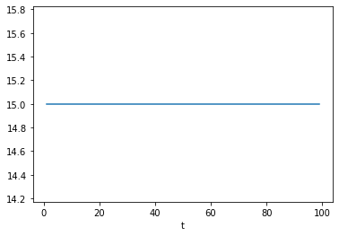

```python
(air / oil).plot()
```